# Reproducible Research: Peer Assessment 1

# By Devon Ly

## A. Loading and preprocessing the data

#### A1. Unzip, load CSV file into a data frame and load additional packages

```r
library(ggplot2)                                                        # Use ggplot2 as our plotting system

unzip("activity.zip")                                                   # Unzip file
Activity_Data <- read.csv( "activity.csv", colClasses = "character" )   # Read CSV file
```

#### A2. Process and transform data in preparation for analysis

```r
Activity_Data$steps    <- as.numeric(Activity_Data$steps)               # Convert character to number
Activity_Data$date     <- as.Date(Activity_Data$date)                   # Convert character to date
Activity_Data$interval <- as.numeric(Activity_Data$interval)            # Convert character to number
```

## B. What is mean total number of steps taken per day?

#### B1. Calculate total number of steps taken per day using the aggregate function

```r
Steps_Per_Day <- aggregate( steps ~ date, data = Activity_Data, FUN = sum )
```

#### B2. Generate histogram of total number of steps taken each day

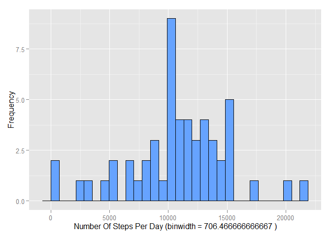

```r
# Divide the steps range into 30 bin
bin_size <- max(Steps_Per_Day$steps) / 30

# Create the histogram
plot1 <- qplot(
                 steps,
                 data = Steps_Per_Day,
                 geom = "histogram",
                 xlab = paste("Number Of Steps Per Day (binwidth =", bin_size, ")" ),
                 ylab = "Frequency",
                 binwidth = bin_size
              )
# Change (horrible) default colour
plot1 <- plot1 + geom_bar(
                            binwidth = bin_size,                        # Supply again to suppress warnings
                            fill = "#66A3FF",                           # Change the bar fill colour
                            color = "black"                             # Change the bar outline colour
                         )
# Display the plot
print(plot1)
```

#### B3. What is the mean steps taken per day?

```r
original_mean <- mean(Steps_Per_Day$steps, na.rm = TRUE)   # Calculate mean ignoring missing values
original_mean
```

```
## [1] 10766.19
```

#### B4. What is the median steps taken per day?

```r
original_median <- median(Steps_Per_Day$steps, na.rm = TRUE) # Calculate median ignoring missing values
original_median
```

```
## [1] 10765
```

## C. What is the average daily activity pattern?

##### C1. Make a time series plot (i.e. type = “l”) of the 5-minute interval (x-axis) and the average number of steps taken, averaged across all days (y-axis)

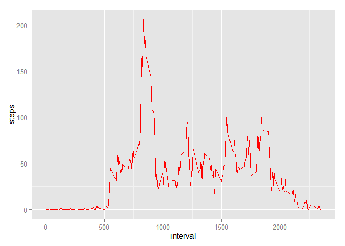

```r
# Generate a data frame of average step by interval
Average_Steps_Per_Interval <- aggregate( steps ~ interval, data = Activity_Data, FUN = mean)

# Create the line graph
plot1 <- ggplot( data = Average_Steps_Per_Interval, aes( x = interval, y = steps, group = 1))
plot1 <- plot1 + geom_line(col = "red")

# Display the plot
print(plot1)
```

#### C2. Which 5-minute interval, on average across all the days in the dataset, contains the maximum number of steps?

```r
Average_Steps_Per_Interval[ Average_Steps_Per_Interval$steps == max(Average_Steps_Per_Interval$steps), 1]
```

```
## [1] 835
```

## D. Imputing missing values

### There are a number of days/intervals where there are missing values (coded as NA). The presence of missing days may introduce bias into some calculations or summaries of the data.

#### D1. Calculate and report the total number of missing values in the dataset (i.e. the total number of rows with NAs)

```r
nrow(Activity_Data[ is.na( Activity_Data$steps), ])
```

```
## [1] 2304
```

#### D2. Devise a strategy for filling in all of the missing values in the dataset. The strategy does not need to be sophisticated. For example, you could use the mean/median for that day, or the mean for that 5-minute interval, etc.

#### D3. Create a new dataset that is equal to the original dataset but with the missing data filled in.

```r
# Merge original data set with our calculated data set containing average steps
Imputed_Data <- merge(
                        Activity_Data,
                        Average_Steps_Per_Interval,
                        by = "interval",
                        all.x = TRUE,
                        suffixes = c("_x","_y")
                      )
# Replace NA values with the mean for that 5 minute interval
Imputed_Data$steps_x[ is.na(Imputed_Data$steps_x)] <- Imputed_Data$steps_y[ is.na(Imputed_Data$steps_x)]
```

#### D4. Make a histogram of the total number of steps taken each day and Calculate

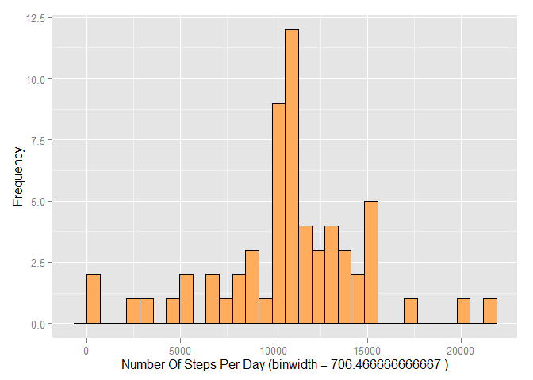

```r
# Calculate steps per day from imputed data
Imputed_Steps_Per_Day <- aggregate( steps_x ~ date, data = Imputed_Data, FUN = sum )

# Divide the steps range into 30 bins
bin_size <- max(Steps_Per_Day$steps) / 30

# Create the histogram
plot1 <- qplot(
                 steps_x,
                 data = Imputed_Steps_Per_Day,
                 geom = "histogram",
                 xlab = paste("Number Of Steps Per Day (binwidth =", bin_size, ")" ),
                 ylab = "Frequency",
                 binwidth = bin_size
              )
# Change (horrible) default colour
plot1 <- plot1 + geom_bar(
                            binwidth = bin_size,                        # Supply again to suppress warnings
                            fill = "#FFAD5C",                           # Change the bar fill colour
                            color = "black"                             # Change the bar outline colour
                         )
# Display the plot
print(plot1)
```

#### and report the mean and median total number of steps taken per day.

The mean using imputed data is

```r
imputed_mean   <- mean(Imputed_Steps_Per_Day$steps_x)     # Calculate mean
imputed_mean
```

```
## [1] 10766.19
```

The median using imputed data is

```r
imputed_median <- median(Imputed_Steps_Per_Day$steps_x)   # Calculate median
imputed_median
```

```
## [1] 10766.19
```

#### Do these values differ from the estimates from the first part of the assignment?

#### Difference with the mean value

```r
paste( "The Mean when NA values ARE NOT imputed = ", original_mean )
```

```
## [1] "The Mean when NA values ARE NOT imputed =  10766.1886792453"
```

```r
paste( "The Mean when NA values ARE imputed is  = ", imputed_mean )
```

```
## [1] "The Mean when NA values ARE imputed is  =  10766.1886792453"
```

```r
if ( imputed_mean == original_mean)
{
  print("The imputed mean does not differ from the mean from original data set")
} else if ( imputed_mean > original_mean)
{
  print("There is difference as the imputed mean is greater than the original mean value")
} else
{
  print("There is a difference as the imputed mean is less than the original mean value")
}
```

```
## [1] "The imputed mean does not differ from the mean from original data set"
```

#### Difference with the median value

```r
paste( "The Median when NA values ARE NOT imputed = ", original_median )
```

```
## [1] "The Median when NA values ARE NOT imputed =  10765"
```

```r
paste( "The Median when NA values ARE imputed is  = ", imputed_median )
```

```
## [1] "The Median when NA values ARE imputed is  =  10766.1886792453"
```

```r
if ( imputed_median == original_median)
{
  print("The imputed median does not differ from the mean from original data set")
} else if ( imputed_median > original_median)
{
  print("There is difference as the imputed median is greater than the original median value")
} else
{
  print("There is a difference as the imputed median is less than the original median value")
}
```

```
## [1] "There is difference as the imputed median is greater than the original median value"
```

#### What is the impact of imputing missing data on the estimates of the total daily number of steps?

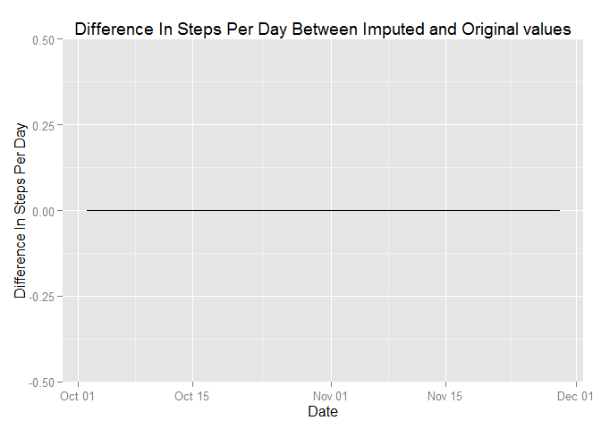

```r
# Calculate the difference between the imputed total steps per day and the original steps per day
Difference_In_Steps_Per_Day <- merge(Steps_Per_Day, Imputed_Steps_Per_Day, by = "date")
Difference_In_Steps_Per_Day$step_diff <-
  Difference_In_Steps_Per_Day$steps_x - Difference_In_Steps_Per_Day$steps

# Plot difference to visual inspect if there is a difference
plot1 <- ggplot( data = Difference_In_Steps_Per_Day, aes( x = date, y = step_diff, group = 1))
plot1 <- plot1 + geom_line()
plot1 <- plot1 + labs( x = "Date", y = "Difference In Steps Per Day",
                       title = "Difference In Steps Per Day Between Imputed and Original values")
print(plot1)
```

## E. Are there differences in activity patterns between weekdays and weekends?

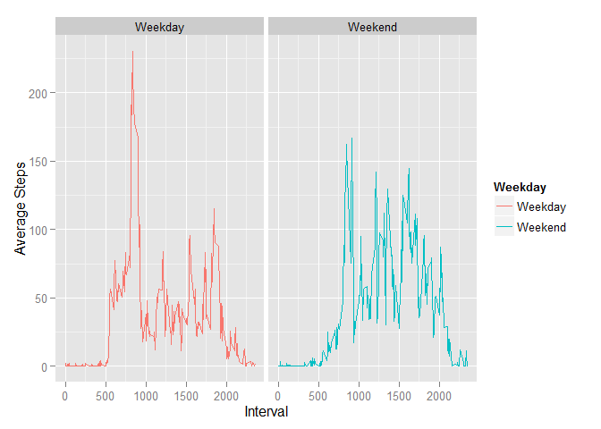

```r
# Create a factor to distinguish between weekday and weekend
Imputed_Data$WeekDay <- as.factor(
                                    ifelse(
                                              weekdays(Imputed_Data$date) %in% c("Saturday","Sunday"),
                                              "Weekend", "Weekday"
                                           )
                                 )

# Create a data frame containing average number of step by the interval and weekday/weekend

Average_Steps_Per_Interval_And_Weekday <- aggregate(
                                                       x  = Imputed_Data$steps_x,
                                                       by  = list(Imputed_Data$interval, Imputed_Data$WeekDay),
                                                       FUN = mean
                                                   )
colnames(Average_Steps_Per_Interval_And_Weekday) <- c("Interval", "Weekday", "Steps")

# Create the line graph
plot1 <- ggplot( data = Average_Steps_Per_Interval_And_Weekday, aes( x     = Interval, y   = Steps,
                                                                     group = Weekday , col = Weekday))
plot1 <- plot1 + labs( y = "Average Steps")
plot1 <- plot1 + facet_wrap( ~ Weekday)
plot1 <- plot1 + geom_line()

print(plot1)
```

```r
# Delete file which we unzipped at the start
unlink("activity.csv")
```